# Background separation for various platinum-based chemotherapeutics

Steve Rozen

2020-07-08

## Introduction

This is an example of background subtraction using the mSigBG package.

In this example we subtract the background signatures of HepG2 and MCF-10A cells from the spectra of cells treated with three platinum-based chemotherapies.

## Libraries and helper functions

```r
# CRAN packages
library(ICAMS)
require(philentropy)
require(factoextra)
require(gplots)
require(nloptr)

# Bioconductor
library(BSgenome.Hsapiens.1000genomes.hs37d5)
# If not available,
# install.packages("BiocManager")
# BiocManager::install("BSgenome.Hsapiens.1000genomes.hs37d5")

# Other
library(mSigBG)
# if not available
# remotes::install_github("steverozen/mSigBG", ref = "1.0-branch")
```

```r
# Plot a single catalog
pcat1 <- function(catalog, ylim = NULL) {
  par(pin = c(5, 1))
  par(mar = c(5, 4, 5, 4))
  par(cex = 0.8)
  par(cex.main = 1.4)
  bp <- ICAMS::PlotCatalog(catalog[ , 1, drop = FALSE],
                           upper   = TRUE,
                           xlabels = TRUE,
                           ylim    = ylim
                           )
  return(invisible(bp$plot.object))
}
```

```r
pcat <- function(catalog) {
  par(pin = c(3*ncol(catalog), 1))
  par(mfrow = c(ncol(catalog), 1))
  par(mar = c(2, 4, 4, 2))
  par(cex = 0.8)
  par(cex.main = 1.4)
  xlabels <- FALSE
  for (i in 1:ncol(catalog)) {
    if (FALSE && i == ncol(catalog)) { # FALSE an experiment
      xlabels <- TRUE
      par(mar = c(4.5, 4, 3, 2))
    }

    ICAMS::PlotCatalog(catalog[ , i, drop = FALSE],
                       upper = (i == 1),
                       xlabels = xlabels)
  }
}
```

## Generate and read input spectra

These are the spectra from cell lines exposed to cisplatin, carboplatin, or oxaliplatin.

### Generate spectra “catalogs” from HepG2 and MCF-10A cisplatin VCF files

These are variant call files (VCFs) from mutations in HepG2 and MCF-10A cells treated with cisplatin.

```r
if (!file.exists("spectra/HepG2_and_MCF10A_Cis.spectra.Rdata")) {
  vcfs <- list.files("vcfs/HepG2_Cis/", full.names = TRUE)
  hepg2.cis <- ICAMS::StrelkaSBSVCFFilesToCatalog(
    files      = vcfs,
    ref.genome = BSgenome.Hsapiens.1000genomes.hs37d5,
    region     = "genome")$catSBS96
  colnames(hepg2.cis) <-
    sub(".vcf", "", x = colnames(hepg2.cis), fixed = TRUE)

  vcfs <- list.files("vcfs/MCF10A_Cis/", full.names = TRUE)
  mcf10a.cis <- ICAMS::StrelkaSBSVCFFilesToCatalog(
    files      = vcfs,
    ref.genome = BSgenome.Hsapiens.1000genomes.hs37d5,
    region     = "genome")$catSBS96
  colnames(mcf10a.cis) <-
    sub(".vcf", "", x = colnames(mcf10a.cis), fixed = TRUE)

  save(hepg2.cis,
       mcf10a.cis,
       file = "spectra/HepG2_and_MCF10A_Cis.spectra.Rdata")

  rm(vcfs)
} else {
  load("spectra/HepG2_and_MCF10A_Cis.spectra.Rdata")
}
```

### Read carboplatin and oxaliplatin spectra catalogs

```r
hepg2.car  <- ICAMS::ReadCatalog("spectra/HepG2_Car.csv",
                                 ref.genome = BSgenome.Hsapiens.1000genomes.hs37d5,
                                 region = "genome",
                                 catalog.type = "counts")

hepg2.oxa  <- ICAMS::ReadCatalog("spectra/HepG2_Oxa.csv",
                                 ref.genome = BSgenome.Hsapiens.1000genomes.hs37d5,
                                 region = "genome",
                                 catalog.type = "counts")

mcf10a.car <- ICAMS::ReadCatalog("spectra/MCF10A_Car.csv",
                                 ref.genome = BSgenome.Hsapiens.1000genomes.hs37d5,
                                 region = "genome",
                                 catalog.type = "counts")
```

### Input as count spectra

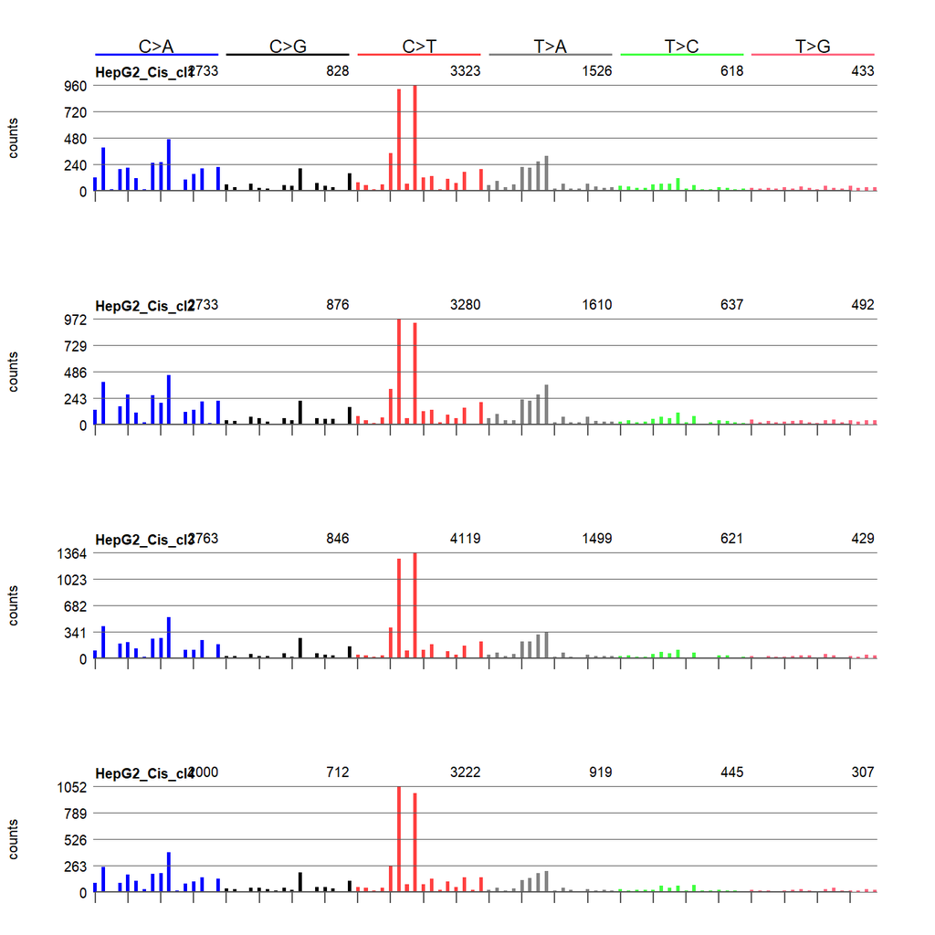

```r
pcat(hepg2.cis)
```

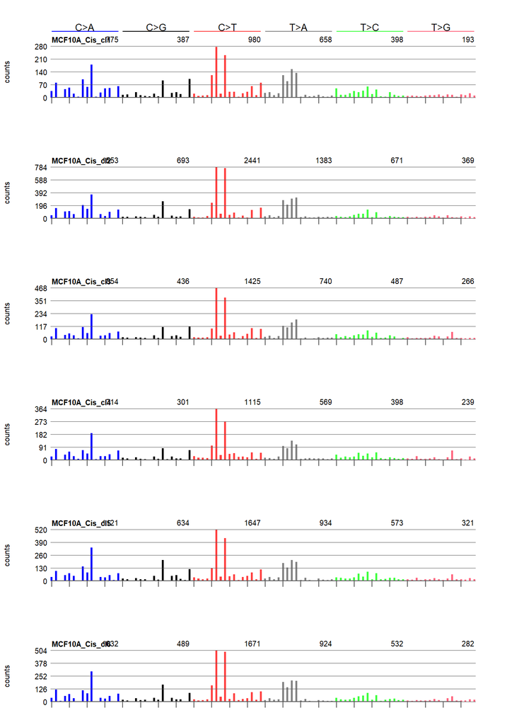

```r
pcat(mcf10a.cis)
```

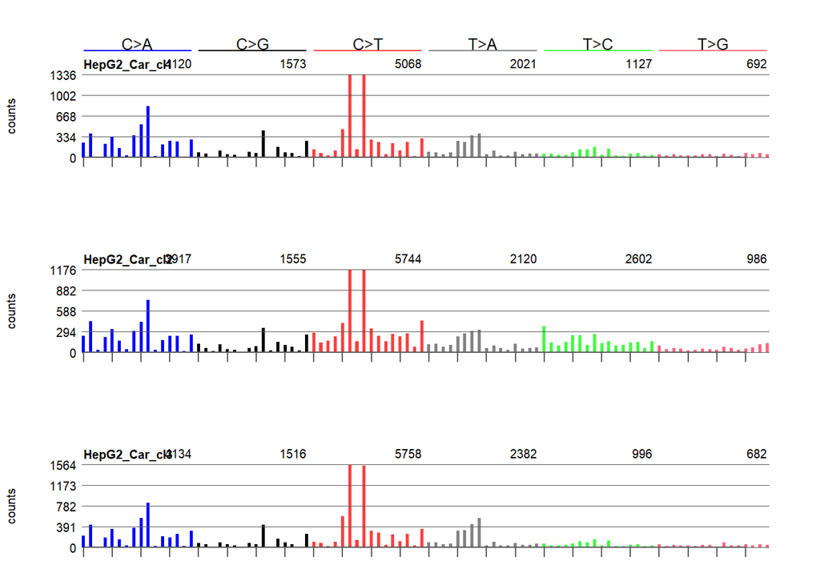

```r
pcat(hepg2.car)
```

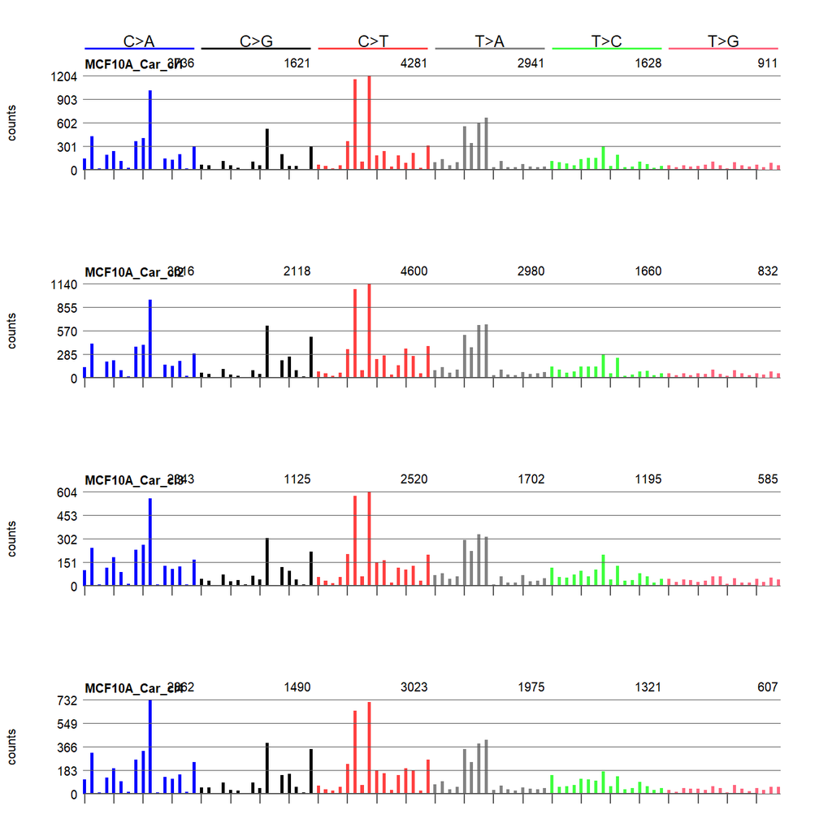

```r
pcat(mcf10a.car)
```

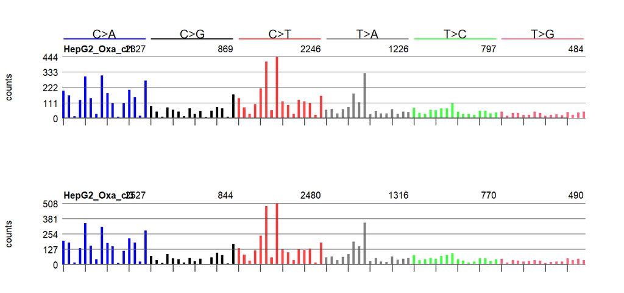

```r
pcat(hepg2.oxa)
```

## Cosine similarity among raw spectra

```r
hepg2.exposures <- list(hepg2.cis, hepg2.car, hepg2.oxa)
names(hepg2.exposures) <-
  c("HepG2.cis.sig", "HepG2.car.sig", "HepG2.oxa.sig")

mcf10a.exposures <- list(mcf10a.cis, mcf10a.car)
names(mcf10a.exposures) <- c("MCF10A.cis.sig", "MCF10.car.sig")
```

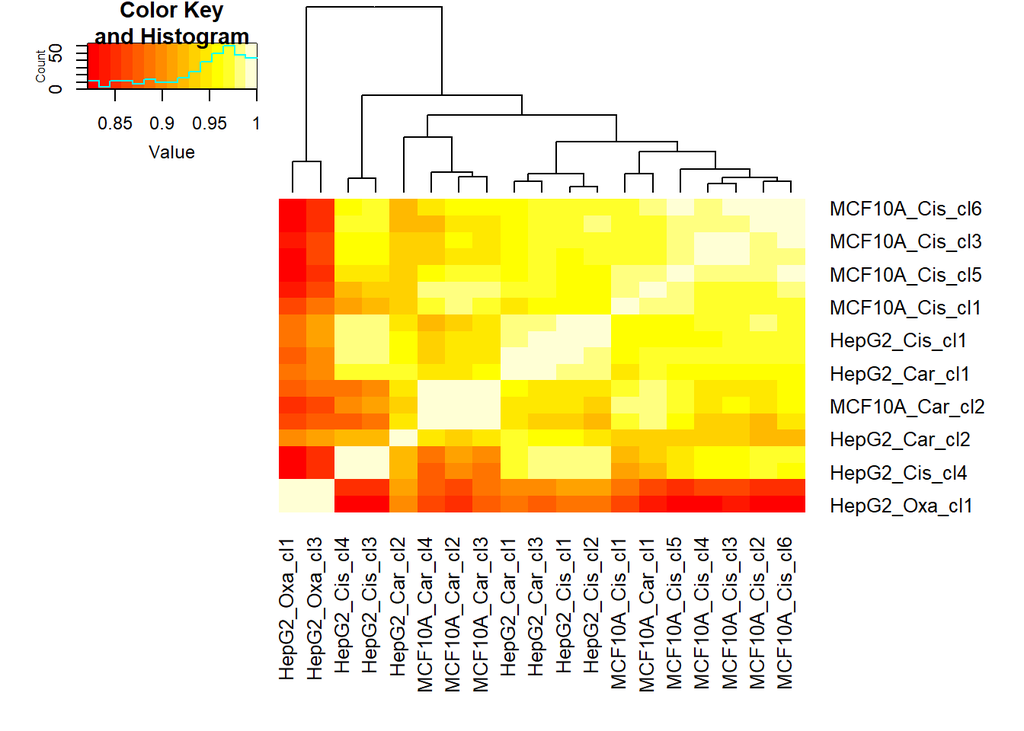

```r
all.spectra <- do.call(cbind, c(hepg2.exposures, mcf10a.exposures))

temp.names <- unlist(lapply(c(hepg2.exposures, mcf10a.exposures), colnames))

colnames(all.spectra) <- temp.names

cosine.sim <- suppressMessages(
  philentropy::distance(t(all.spectra), method = "cosine"))
rownames(cosine.sim) <- colnames(all.spectra)
colnames(cosine.sim) <- colnames(all.spectra)
gplots::heatmap.2(x = cosine.sim,
                  dendrogram = "column",
                  margins = c(9, 9),
                  cex.axis = 0.5,
                  symm = TRUE,
                  trace = "none")
```

## Principal components of raw spectra

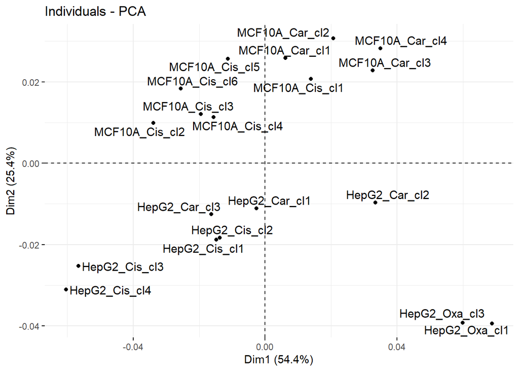

```r
all.spectra.as.sigs <-
  ICAMS::TransformCatalog(all.spectra,
                          target.catalog.type = "counts.signature")

pc <- prcomp(t(all.spectra.as.sigs), center = TRUE, scale = FALSE, retx = TRUE)

factoextra::fviz_pca_ind(pc, repel = TRUE)
```

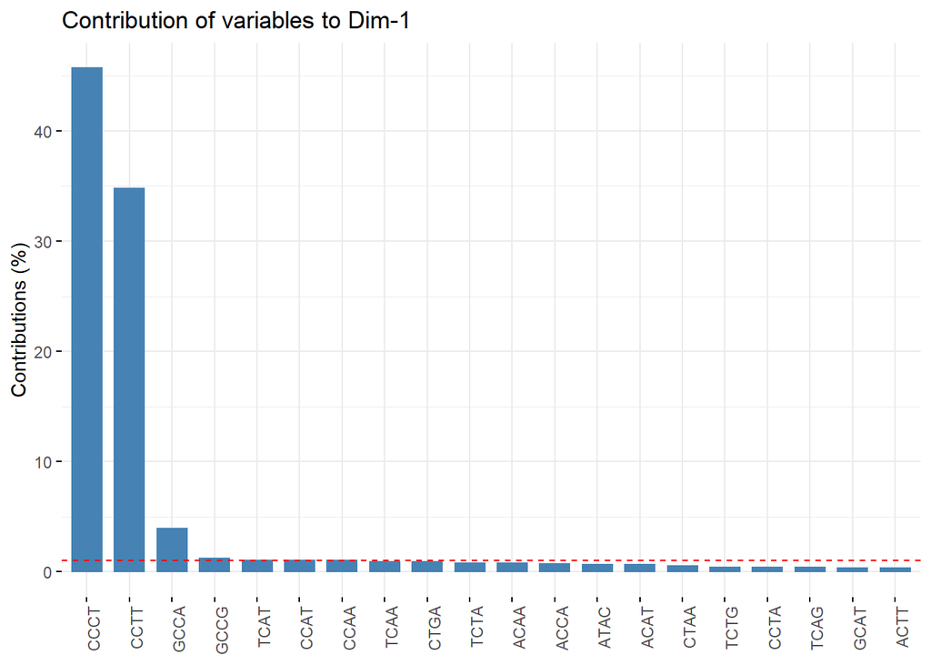

```r
factoextra::fviz_contrib(
  pc, choice   = "var",
  top          = 20,
  xtickslab.rt = 90)
```

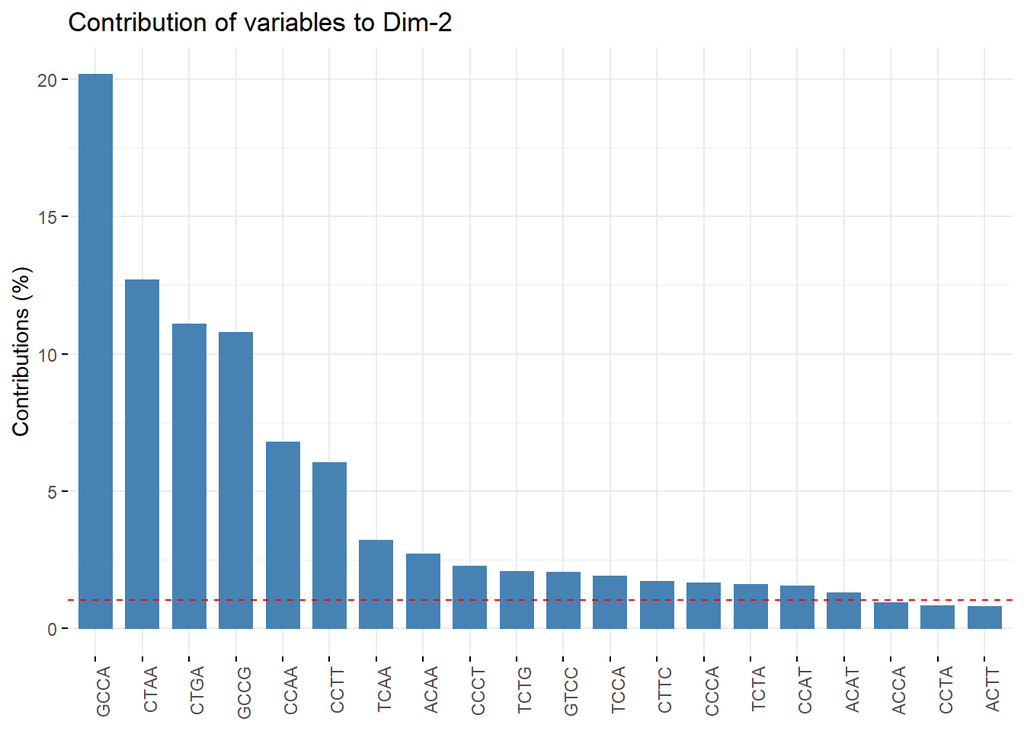

```r
factoextra::fviz_contrib(
  pc, choice   = "var",
  top          = 20,
  axes         = 2,
  xtickslab.rt = 90)
```

## Background signatures, for refrence

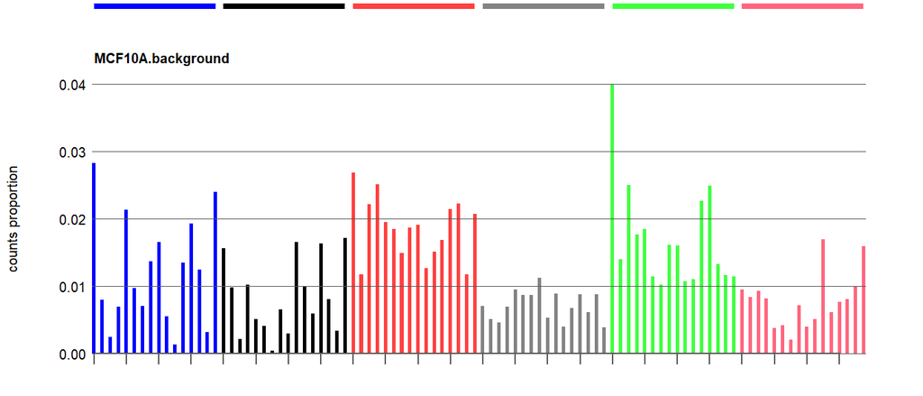

```r
pcat(mSigBG::background.info[["MCF10A"]]$background.sig)
```

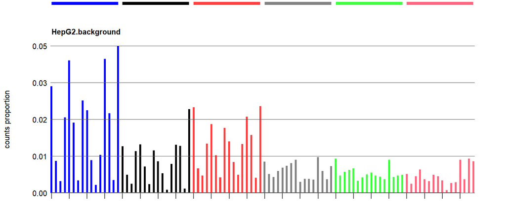

```r
pcat(mSigBG::background.info[["HepG2"]]$background.sig)
```

## Separate the background and target signatures

```r
one.separation <- function(sig.name, sig.list, bg.sig.info, my.seed = 101010) {

  set.seed(my.seed, kind = "L'Ecuyer-CMRG")

  spectra <- sig.list[[sig.name]]

  if (is.null(attr(spectra, "abundance"))) {
    stop("NULL abundance for ", sig.name)
  }

  ret <- SeparateSignatureAndSpectra(
    spectra          = spectra,
    bg.sig.info      = bg.sig.info,
    m.opts           = NULL,
    start.b.fraction = 0.5,
    sig.name         = sig.name
  )

  return(ret)
}

if (!file.exists("all.separated.Rdata")) {
  hepg2.separated <- lapply(X           = names(hepg2.exposures),
                            FUN         = one.separation,
                            sig.list    = hepg2.exposures,
                            bg.sig.info = background.info[["HepG2"]])
  names(hepg2.separated) <- names(hepg2.exposures)
}
```

```r
if (!file.exists("all.separated.Rdata")) {
  mcf10a.separated <- lapply(X           = names(mcf10a.exposures),
                             FUN         = one.separation,
                             sig.list    = mcf10a.exposures,
                             bg.sig.info = background.info[["MCF10A"]])
  names(mcf10a.separated) <- names(mcf10a.exposures)

  all.separated <- c(hepg2.separated, mcf10a.separated)
  save(all.separated, file = "all.separated.Rdata")
} else {
  load("all.separated.Rdata")
}
```

### Sanity check: exposures to background signature

This is a sanity check. The number of mutations assigned to the background signature should be reasonable given the distribution in untreated cell lines.

```r
background.info[["HepG2"]]$count.nbinom.mu
```

```
## [1] 1534
```

```r
background.info[["MCF10A"]]$count.nbinom.mu
```

```
## [1] 949.6667
```

```r
lapply(all.separated,
       function(x) {
         exposures <- x$exposures.to.bg.sig
         names <- colnames(x$inferred.bg.spectra)
         names(exposures) <- sub("-inf.bg.spect", "", names, fixed = TRUE)
         return(exposures)
       })
```

```
## $HepG2.cis.sig
## HepG2_Cis_cl1 HepG2_Cis_cl2 HepG2_Cis_cl3 HepG2_Cis_cl4
##     1609.5822     1648.5881      945.5243     1230.5412
##
## $HepG2.car.sig
## HepG2_Car_cl1 HepG2_Car_cl2 HepG2_Car_cl3
##     1305.6340     2738.5838      950.5149
##
## $HepG2.oxa.sig
## HepG2_Oxa_cl1 HepG2_Oxa_cl3
##      1496.360      1293.637
##
## $MCF10A.cis.sig
## MCF10A_Cis_cl1 MCF10A_Cis_cl2 MCF10A_Cis_cl3 MCF10A_Cis_cl4 MCF10A_Cis_cl5
##       545.5064       478.4482       519.5116       641.6435       693.7527
## MCF10A_Cis_cl6
##       522.5169
##
## $MCF10.car.sig
## MCF10A_Car_cl1 MCF10A_Car_cl2 MCF10A_Car_cl3 MCF10A_Car_cl4
##       762.6273       782.8915       897.3622       994.4202
```

## Signatures based on inferred target spectra with uncertainty

The bars show the maximum and minimum proportions across all input spectra.

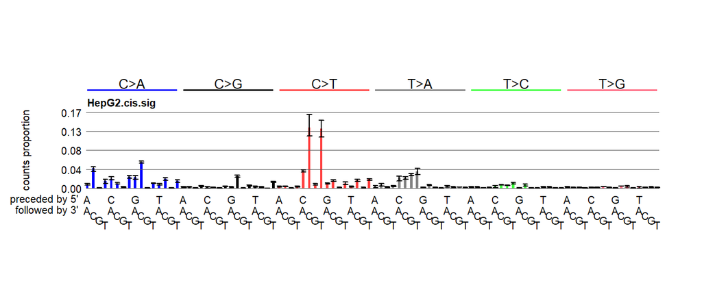

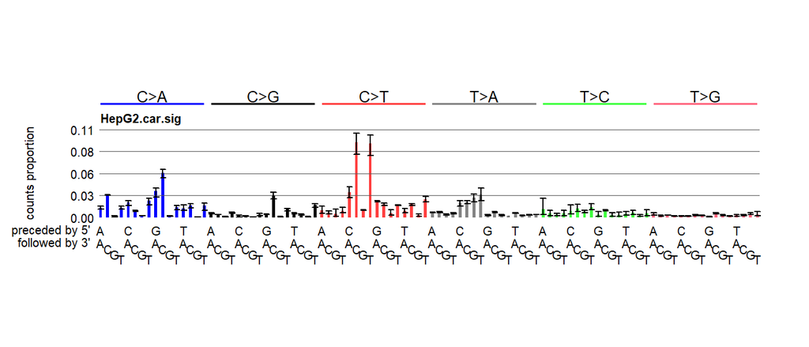

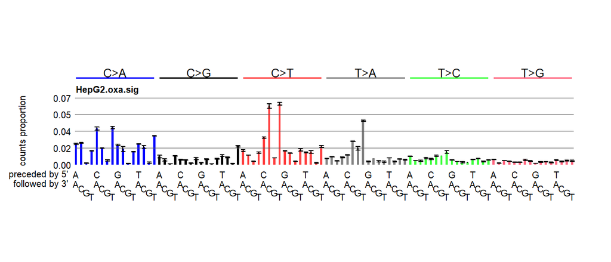

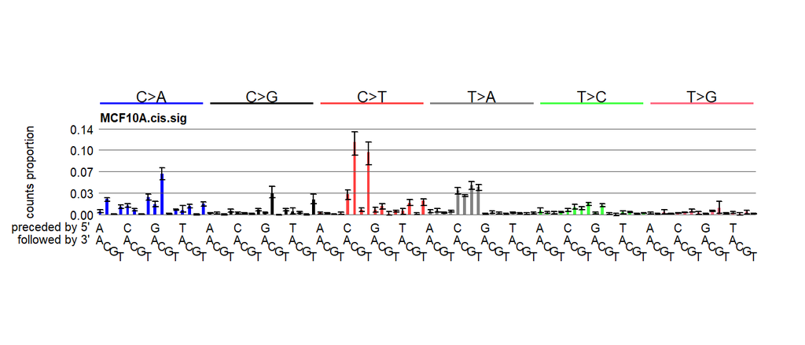

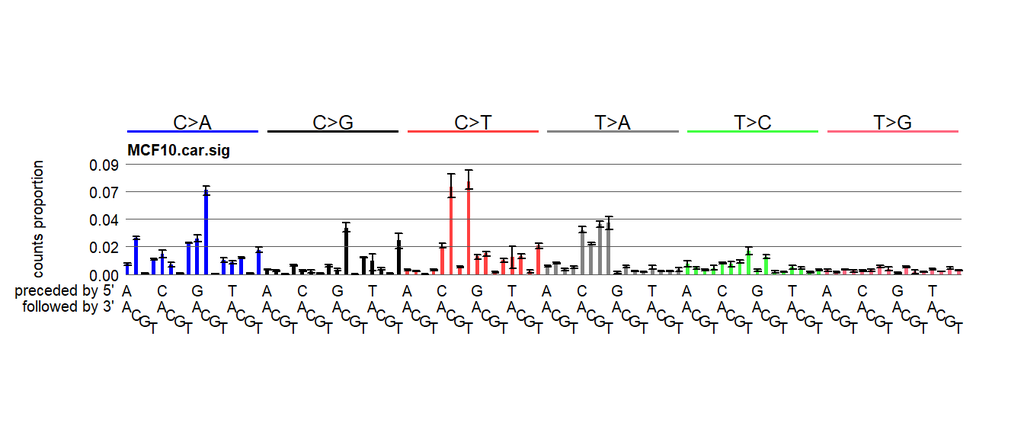

```r
par(mfrow = c(1, 1))
par(mar = c(7, 5, 7, 2))
par(cex = 0.8)
par(cex.main = 1.4)
for (test.name in names(all.separated)) {
  PlotSpectraAsSigsWithUncertainty(
    all.separated[[test.name]]$inferred.target.spectra,
    title = test.name)
}
```

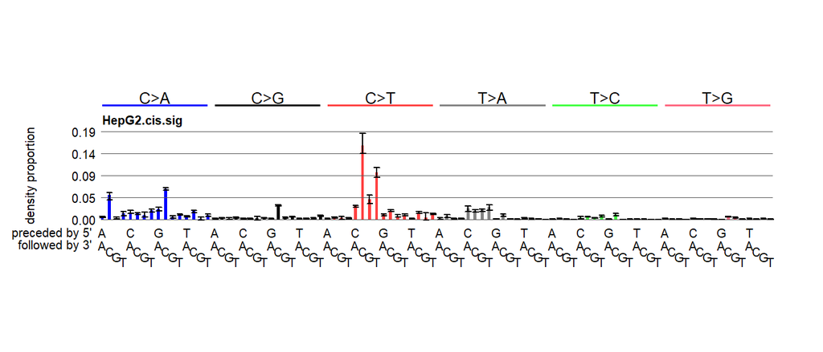

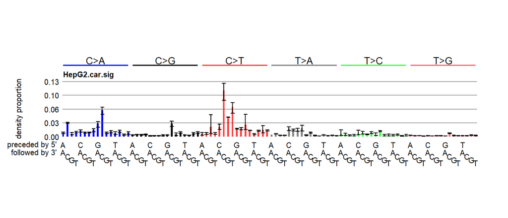

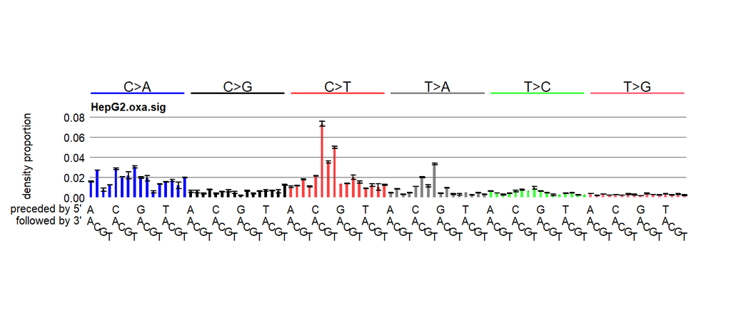

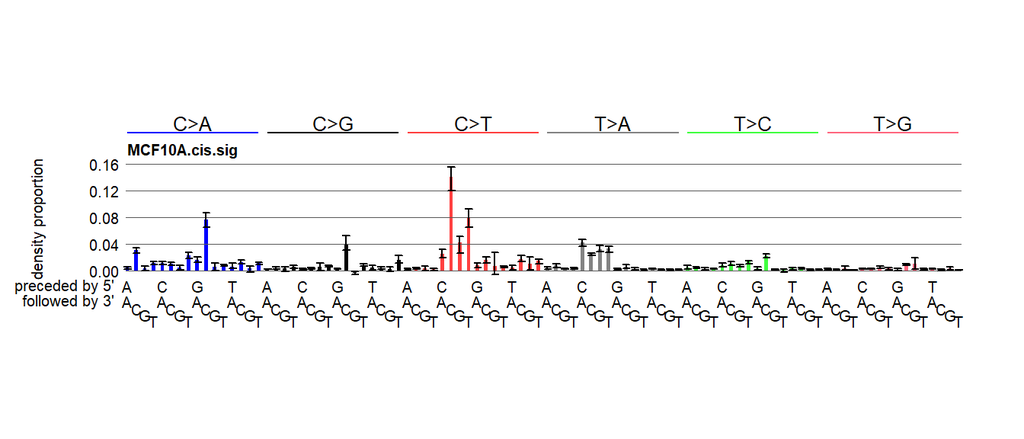

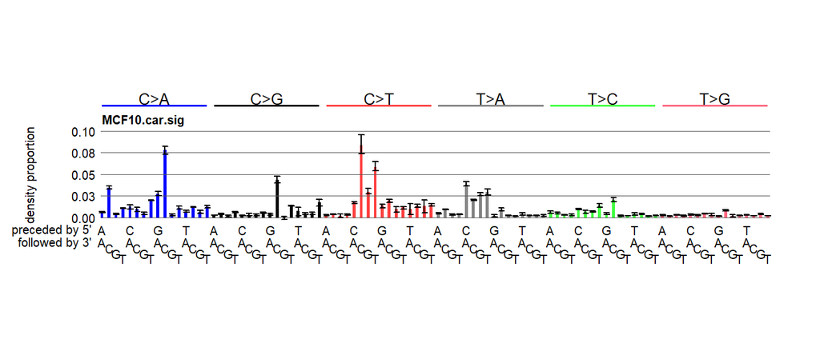

```r
par(mfrow = c(1, 1))
par(mar = c(7, 5, 7, 2))
par(cex = 0.8)
par(cex.main = 1.4)
for (test.name in names(all.separated)) {
  d.spect <- ICAMS::TransformCatalog(
    all.separated[[test.name]]$inferred.target.spectra,
    target.catalog.type = "density")
  PlotSpectraAsSigsWithUncertainty(
    d.spect,
    title = test.name)
}
```